# Suslik Capture-Recapture Analysis Miroslav 2019

Fernando Mateos-Gonzalez (ALKA Wildlife)

This report analises data from capture-recapture sessions in Miroslav during 17-18-19 April, 24-25 April and 15-19, 24 July 2019, in order to calculate the density of the population.

## Analysis

We used the data below, which combines the information obtained from our captures and the trap locations. The analysis was performed using the package ‘secr’ version 3.2.1 and R 3.6.1.

```
Session 2
More than one detection per detector per occasion at binary detector(s)
$`1`
Object class       capthist
Detector type      proximity
Detector number    20
Average spacing    13.57938 m
x-range            -623778.5 -623653.2 m
y-range            -1187164 -1187091 m

Counts by occasion
```

|  | 1 | 2 | 3 | 4 | 5 | Total |
| --- | --- | --- | --- | --- | --- | --- |
| n | 15 | 23 | 15 | 11 | 14 | 78 |
| u | 15 | 22 | 11 | 7 | 11 | 66 |
| f | 56 | 8 | 2 | 0 | 0 | 66 |
| M(t+1) | 15 | 37 | 48 | 55 | 66 | 66 |
| losses | 0 | 0 | 0 | 0 | 0 | 0 |
| detections | 15 | 23 | 15 | 11 | 14 | 78 |
| detectors visited | 8 | 13 | 9 | 10 | 10 | 50 |
| detectors used | 20 | 20 | 20 | 20 | 20 | 100 |

```
$`2`
Object class       capthist
Detector type      proximity
Detector number    20
Average spacing    13.57938 m
x-range            -623778.5 -623653.2 m
y-range            -1187164 -1187091 m

Counts by occasion
```

|  | 1 | 2 | 3 | 4 | 5 | 6 | Total |
| --- | --- | --- | --- | --- | --- | --- | --- |
| n | 23 | 27 | 16 | 19 | 8 | 7 | 100 |
| u | 23 | 22 | 12 | 11 | 5 | 3 | 76 |
| f | 59 | 11 | 5 | 1 | 0 | 0 | 76 |
| M(t+1) | 23 | 45 | 57 | 68 | 73 | 76 | 76 |
| losses | 0 | 0 | 0 | 0 | 0 | 0 | 0 |
| detections | 24 | 27 | 17 | 21 | 8 | 7 | 104 |
| detectors visited | 14 | 12 | 12 | 15 | 8 | 7 | 68 |
| detectors used | 20 | 20 | 20 | 20 | 20 | 20 | 120 |

```
NA
```

*n number of distinct individuals detected on each occasion t*  
u number of individuals detected for the first time on each occasion t  
*f number of individuals detected on exactly t occasions*  
M(t+1) cumulative number of detected individuals on each occasion t

### The following plots show the trap array and the consecutive captures of each individual.

```
screen layout does not allow for all sessions and some plots may be lost; set par mfrow
```

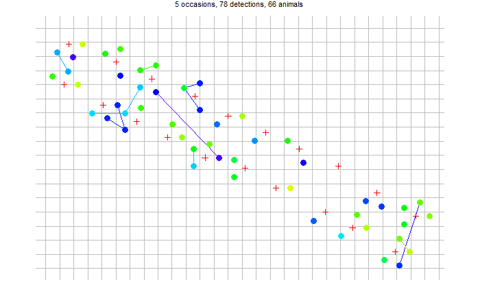

```
track for repeat detections on same occasion joins points in arbitrary sequence
```

```
  1   2
 78 104
```

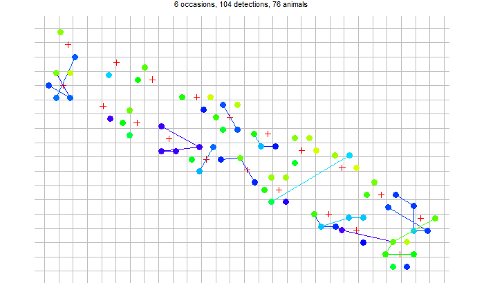

The most important insight from these figures is that individuals tend to be recaptured near their site of first capture. This is expected when the individuals of a species occupy home ranges. In SECR models the tendency for detections to be localised is reflected in the spatial scale parameter σ.

### Successive trap-revealed movements and distances shown below

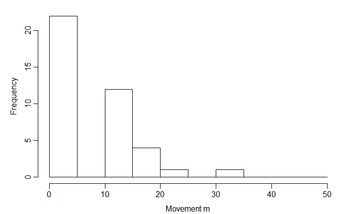

We will employ the estimate of the spatial scale σ from the July session (6.21) to fit the simplest possible SECR model with function secr.fit.

```
secr.fit(capthist = multi, buffer = 4 * 6.21, verify = FALSE,
    biasLimit = NA, trace = FALSE)
secr 3.2.1, 11:31:23 13 Nov 2019

$`1`
Detector type      proximity
Detector number    20
Average spacing    13.57938 m
x-range            -623778.5 -623653.2 m
y-range            -1187164 -1187091 m

$`2`
Detector type      proximity
Detector number    20
Average spacing    13.57938 m
x-range            -623778.5 -623653.2 m
y-range            -1187164 -1187091 m

            1   2
Occasions   5   6
Detections 78 104
Animals    66  76
Detectors  20  20

Model           :  D~1 g0~1 sigma~1
Fixed (real)    :  none
Detection fn    :  halfnormal
Distribution    :  poisson
N parameters    :  3
Log likelihood  :  -400.248
AIC             :  806.4959
AICc            :  806.6698

Beta parameters (coefficients)
```

|  | beta | SE.beta | lcl | ucl |
| --- | --- | --- | --- | --- |
| D | 5.583114 | 0.15495199 | 5.279413 | 5.886814 |
| g0 | -2.156845 | 0.22702132 | -2.601799 | -1.711891 |
| sigma | 1.935015 | 0.09169638 | 1.755294 | 2.114737 |

```
Variance-covariance matrix of beta parameters
                 D          g0        sigma
D      0.024010119 -0.01368840 -0.004682774
g0    -0.013688402  0.05153868 -0.013199439
sigma -0.004682774 -0.01319944  0.008408225

Fitted (real) parameters evaluated at base levels of covariates

 session = 1
```

|  | link | estimate | SE.estimate | lcl | ucl |
| --- | --- | --- | --- | --- | --- |
| D | log | 265.8982129 | 41.45001145 | 196.25469102 | 360.2556415 |
| g0 | logit | 0.1036933 | 0.02109959 | 0.06902276 | 0.1529186 |
| sigma | log | 6.9241504 | 0.63625647 | 5.78514699 | 8.2874055 |

```
 session = 2
```

|  | link | estimate | SE.estimate | lcl | ucl |
| --- | --- | --- | --- | --- | --- |
| D | log | 265.8982129 | 41.45001145 | 196.25469102 | 360.2556415 |
| g0 | logit | 0.1036933 | 0.02109959 | 0.06902276 | 0.1529186 |
| sigma | log | 6.9241504 | 0.63625647 | 5.78514699 | 8.2874055 |

```
NA
```

The report comprises:  
• function call and time stamp  
• summary of the data  
• description of the model, including the maximized log likelihood, Akaike’s Information Criterion AIC  
• estimates of model coefficients (beta parameters)  
• estimates of variance-covariance matrix of the coefficients  
• estimates of the ‘real’ parameters

. The estimated density is 266 susliks per hectare, 95% confidence interval 196-360 susliks per hectare  
. The other two real parameters jointly determine the detection function, plotted below with 95% confidence limits

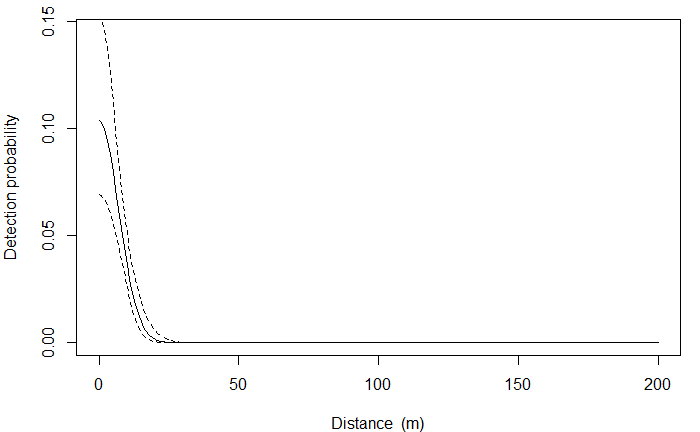

The theory of SECR tells us that buffer width is not critical as long as it is wide enough that animals at the edge have effectively zero chance of appearing in our sample.We check that for the present model with the function esa.plot.

The estimated density has easily reached a plateau at the chosen buffer width (dashed red line):

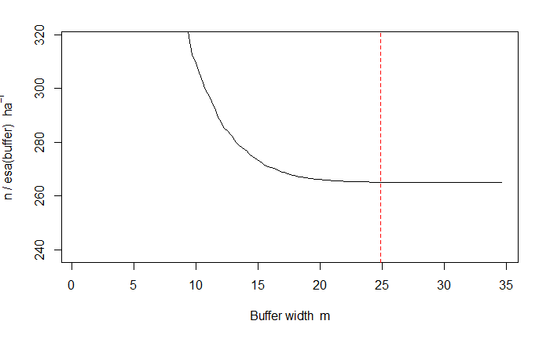

## Homeranges

Mean distance in meters, between consecutive capture locations, pooled over individuals, per capture session (e.g. Efford 2004).

```
[[1]]
[1] 9.868384

[[2]]
[1] 6.047118
```

MMDM (for ‘Mean Maximum Distance Moved’) is the average maximum distance (in m) between detections of each individual i.e. the observed range length averaged over individuals (Otis et al. 1978).

```
[[1]]
[1] 10.51957

[[2]]
[1] 8.131099
```

RPSV (for ‘Root Pooled Spatial Variance’) is a measure of the 2-D dispersion of the locations at which individual animals are detected, pooled over individuals (cf Calhoun and Casby 1958, Slade and Swihart 1983).

```
[[1]]
[1] 10.05093

[[2]]
[1] 7.759548
```